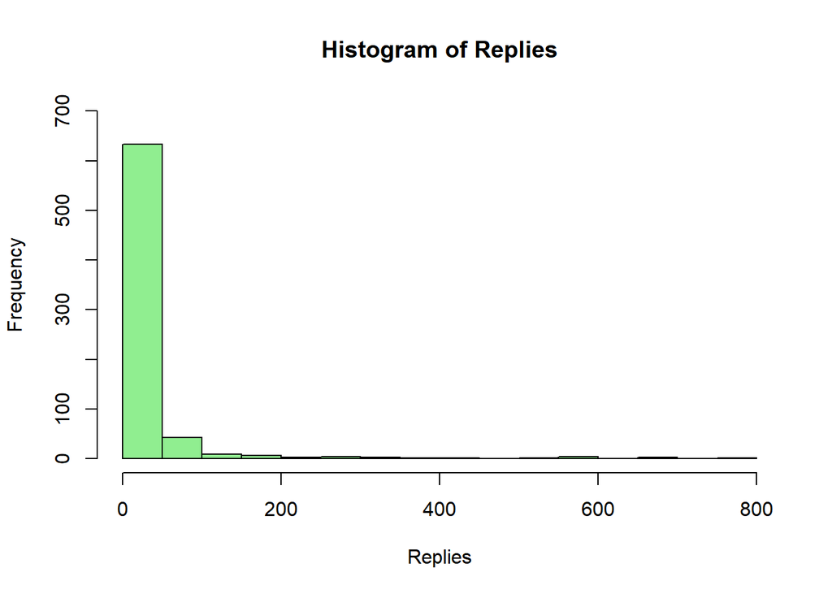

```r
hist(Replies, ylim = c(0, 700), col="lightgreen")
```

#Histogram of Children

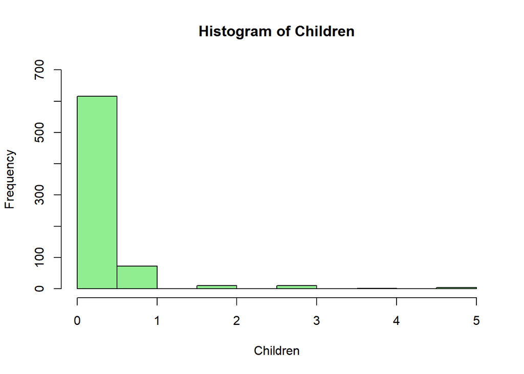

```r
hist(Children, ylim = c(0, 700), col="lightgreen")
```

#Histogram of Likes

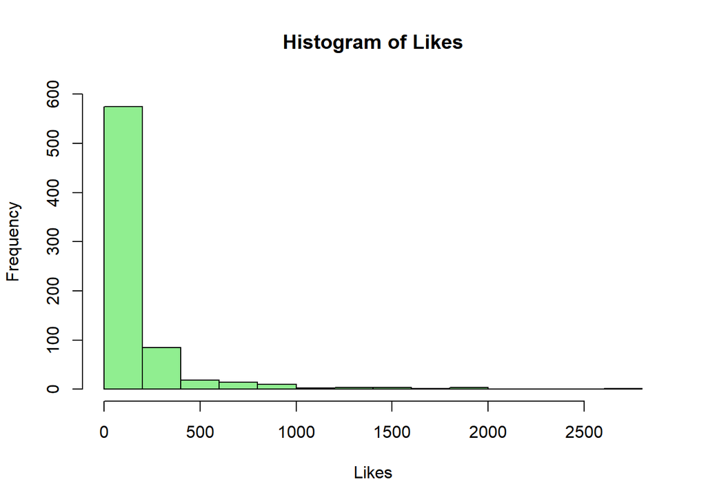

```r
hist(Likes, ylim=c(0, 600), col="lightgreen")
```

#Histogram of Events and Friends

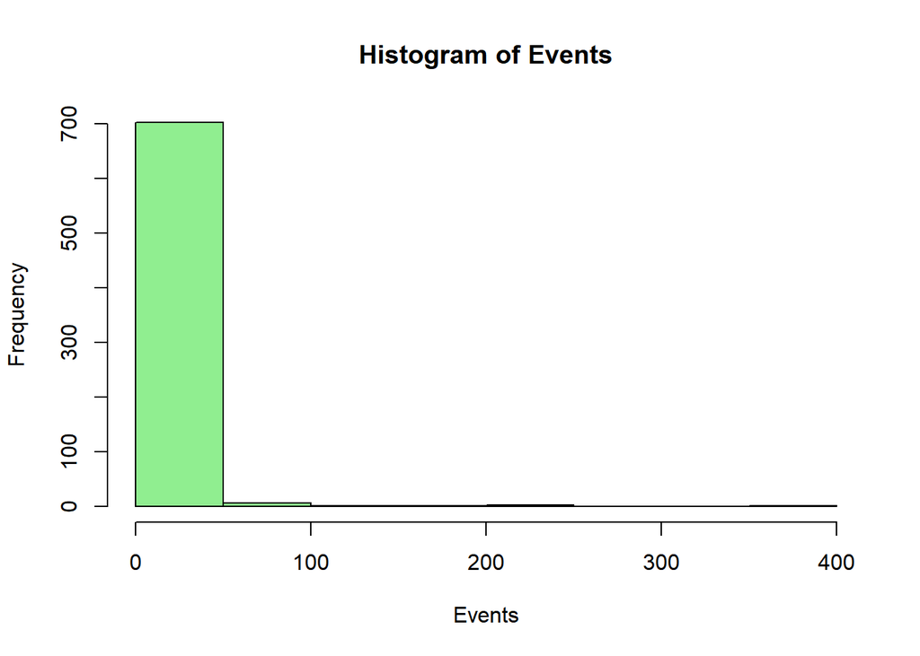

```r
hist(Events, col="lightgreen")
```

#Histogram of Events and Friends

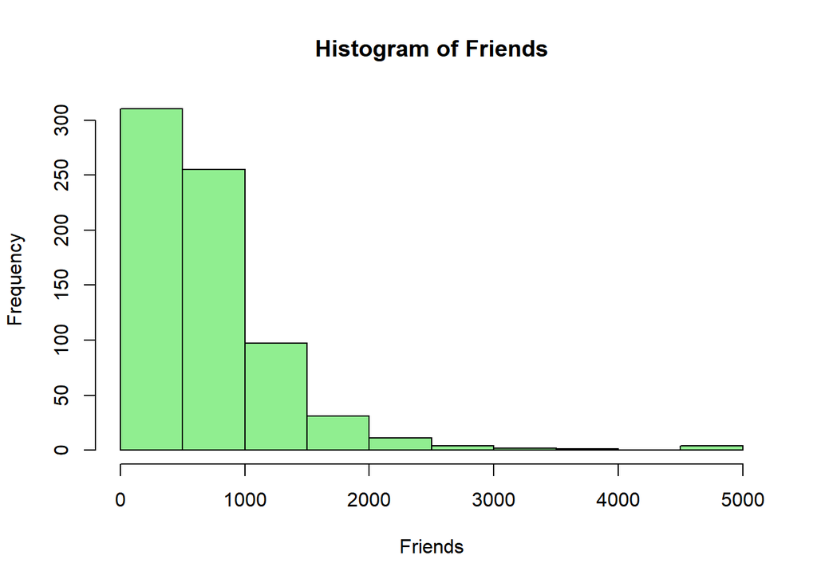

```r
hist(Friends, xlab="Friends", main="Histogram of Friends", col="lightgreen")
```

#Comments on Section3:

#1. Age: The shape is right skewed where mean (24.4) is greater than median (22). Histogram: Most of the data is on left side of the Histogram and it has longer tail on the right side. The distribution of the data is not symmetric. In box plot, Median is close to first quartile. There are few outliers with maximum age as 81 in the dataset.

#2. Photos: The shape is right skewed where mean (723.9) is greater than median(320 Histogram: Most of the data is on left side of the Histogram and it has longer tail on the right side. The distribution of the data is not symmetric. In box plot, Median is close to first quartile. There are few outliers with maximum number of photos as 11995.

#3. Number of Tags: The shape is right skewed where mean (458) is greater than median (250). Histogram: Most of the data is on left side of the Histogram and it has longer tail on the right side. The distribution of the data is not symmetric. In box plot, Median is close to first quartile. There are few outliers with maximum tag as 10460 in the dataset.

#4. Albums: The shape is right skewed where mean (18.95) is greater than median (12). Histogram: Most of the data is on left side of the Histogram and it has longer tail on the right side. The distribution of the data is not symmetric. In box plot, Median is close to first quartile. There are few outliers with maximum albums as 172 in the dataset.

#5. Posts: The shape is right skewed where mean (37.57) is greater than median (15). Histogram: Most of the data is on left side of the Histogram and it has longer tail on the right side. The distribution of the data is not symmetric. In box plot, Median is close to first quartile. There are few outliers with maximum number of posts as 794 in the dataset.

#6. Replies: The shape is right skewed where mean (34.8) is greater than median (14). Histogram: Most of the data is on left side of the Histogram and it has longer tail on the right side. The distribution of the data is not symmetric. In box plot, Median is close to first quartile. There are few outliers with maximum number of posts as 752 in the dataset.

#7. Children: The shape is right skewed where mean (0.211) is greater than median (0). Histogram: Most of the data is on left side of the Histogram and it has longer tail on the right side. The distribution of the data is not symmetric. In box plot, Median is close to first quartile.

#8. Likes: The shape is right skewed where mean (144.8) is greater than median (59). Histogram: Most of the data is on left side of the Histogram and it has longer tail on the right side. The distribution of the data is not symmetric. In box plot, Median is close to first quartile. There are few outliers with maximum number of likes as 2619 in the dataset.

#9. Events: The shape is right skewed where mean (8.85) is greater than median (4). Histogram: Most of the data is on left side of the Histogram and it has longer tail on the right side. The distribution of the data is not symmetric. In box plot, Median is close to first quartile. There are few outliers with maximum number of likes as 396 in the dataset.

#10. Friends: The shape is right skewed where mean (695.85) is greater than median (563). Histogram: Most of the data is on left side of the Histogram and it has longer tail on the right side. The distribution of the data is not symmetric. In box plot, Median is close to first quartile. There are few outliers with maximum number of likes as 4999 in the dataset.

#All non-binary variables are right skewed. Frequency tabulations were drawn for all non-binary variables and values were rounded off to two decimal places.

#(4) Propose a regression model to predict number of Friends by selecting significant non-binary variables. Estimate the model and describe the fit (R-squared, etc.). Which of your proposed predictors are significant? (Note: need to use the correlation map / heatmap to provide quantitative values for significance). #a. Correlation heatmap for all variables.

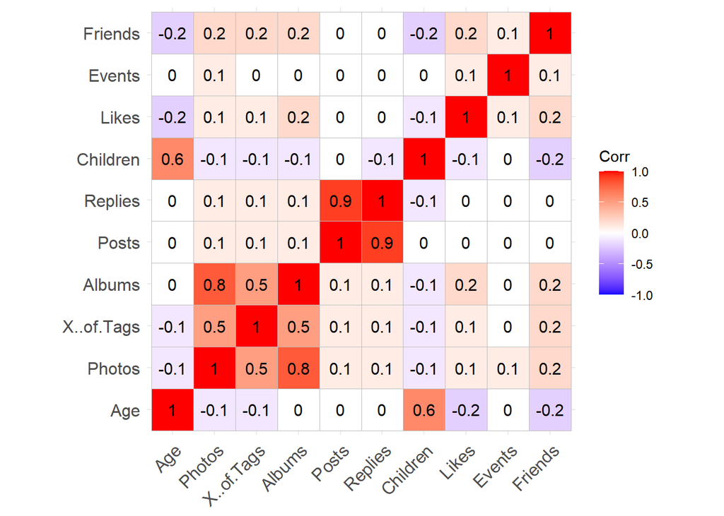

```r
library(ggplot2)
library(ggcorrplot)
fbfriend1 <- data.frame(Age, Photos, X..of.Tags, Albums, Posts,Replies, Children, Likes, Events,Friends)
corr <- round(cor(fbfriend1), 1)
ggcorrplot(corr, lab = TRUE)
```

#b. Multiple regrssion model #Model1: All non-binary variables are used for regression model.

```r
model1<-lm(Friends ~ Age + Photos + X..of.Tags + Albums + Posts + Replies +  Children + Likes + Events)
summary(model1)
```

```
##
## Call:
## lm(formula = Friends ~ Age + Photos + X..of.Tags + Albums + Posts +
##     Replies + Children + Likes + Events)
##
## Residuals:
##     Min      1Q  Median      3Q     Max
## -1219.7  -331.9  -108.5   160.9  4436.1
##
## Coefficients:
##              Estimate Std. Error t value Pr(>|t|)
## (Intercept) 768.30950   93.29374   8.235 8.68e-16 ***
## Age          -9.60237    3.71960  -2.582  0.01004 *
## Photos        0.05526    0.02783   1.985  0.04749 *
## X..of.Tags    0.10649    0.03558   2.993  0.00286 **
## Albums        0.78894    1.60439   0.492  0.62306
## Posts         1.09753    0.61740   1.778  0.07589 .
## Replies      -1.14086    0.66943  -1.704  0.08878 .
## Children    -51.67401   39.27311  -1.316  0.18868
## Likes         0.40162    0.08225   4.883 1.29e-06 ***
## Events        1.06155    0.87547   1.213  0.22571
## ---
## Signif. codes:  0 '***' 0.001 '**' 0.01 '*' 0.05 '.' 0.1 ' ' 1
##
## Residual standard error: 558.2 on 705 degrees of freedom
## Multiple R-squared:  0.1439, Adjusted R-squared:  0.133
## F-statistic: 13.17 on 9 and 705 DF,  p-value: < 2.2e-16
```

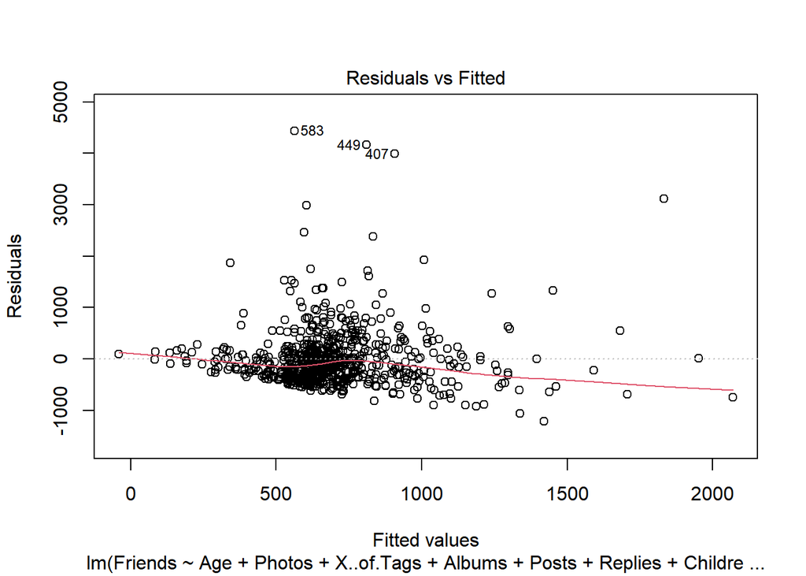

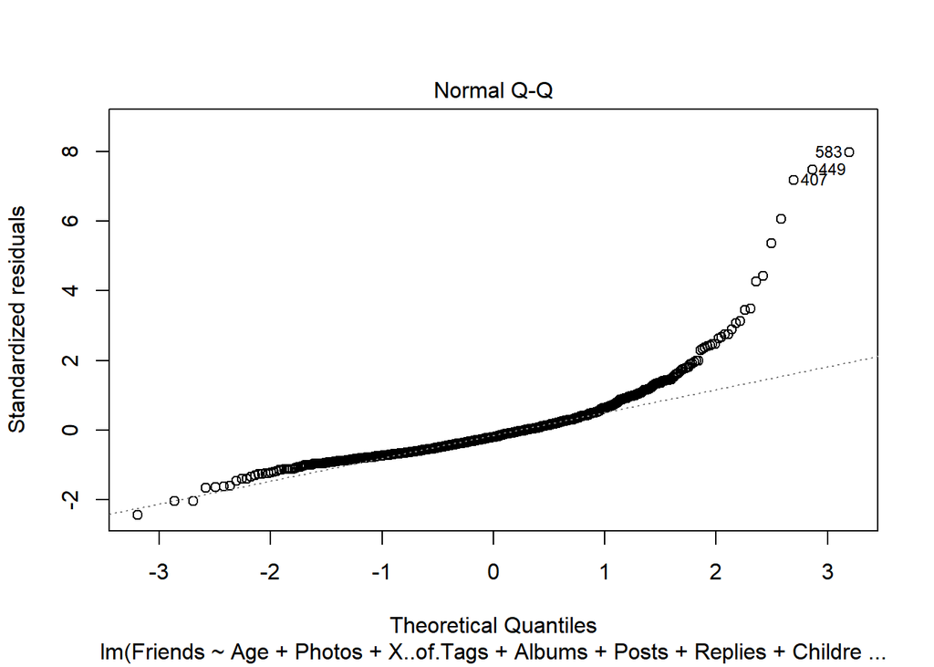

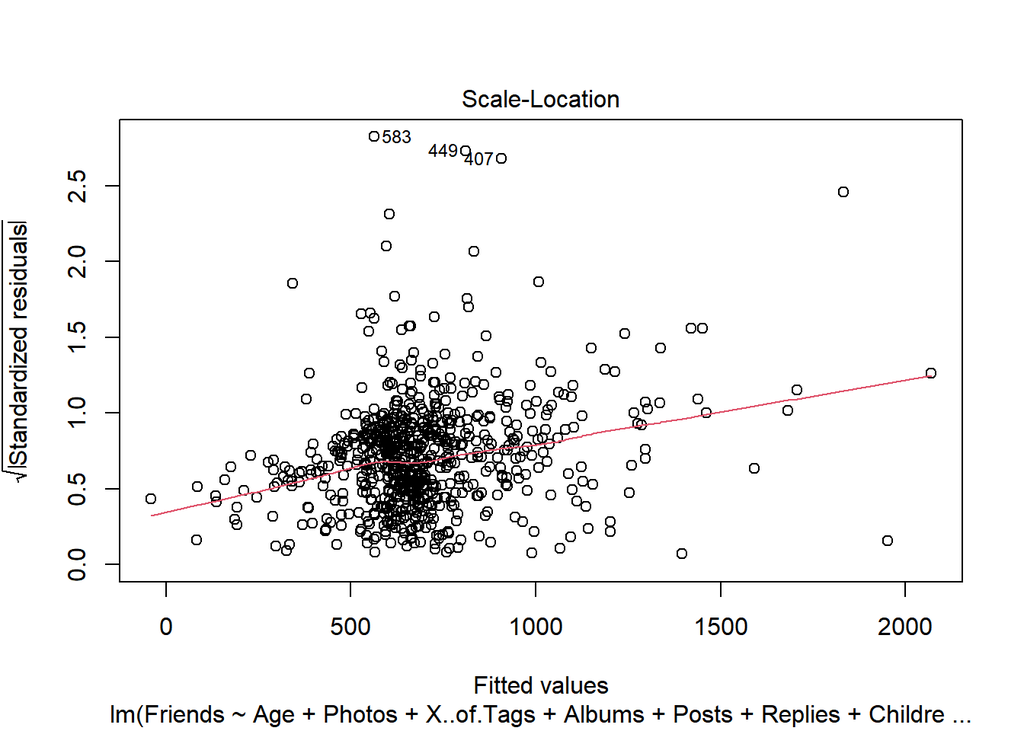

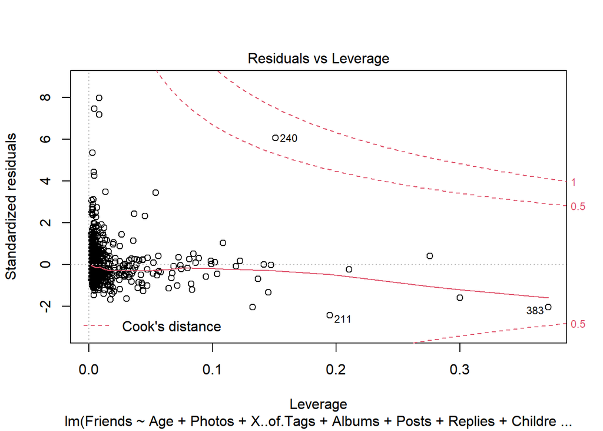

```r
plot(model1)
```

#Model2: Age, Photos, X..of.Tags, Posts, Replies, Likes variables are used for regression model.

```r
model2 <- update(model1, ~. -Children- Events- Albums)
summary(model2)
```

```
##
## Call:
## lm(formula = Friends ~ Age + Photos + X..of.Tags + Posts + Replies +
##     Likes)
##
## Residuals:
##     Min      1Q  Median      3Q     Max
## -1262.7  -328.3  -104.0   167.1  4476.0
##
## Coefficients:
##              Estimate Std. Error t value Pr(>|t|)
## (Intercept) 830.13970   83.44118   9.949  < 2e-16 ***
## Age         -12.11913    3.06622  -3.952 8.51e-05 ***
## Photos        0.06742    0.01957   3.445 0.000604 ***
## X..of.Tags    0.11194    0.03441   3.253 0.001195 **
## Posts         1.10514    0.61748   1.790 0.073920 .
## Replies      -1.13767    0.66885  -1.701 0.089395 .
## Likes         0.41090    0.08167   5.032 6.18e-07 ***
## ---
## Signif. codes:  0 '***' 0.001 '**' 0.01 '*' 0.05 '.' 0.1 ' ' 1
##
## Residual standard error: 558.4 on 708 degrees of freedom
## Multiple R-squared:  0.1399, Adjusted R-squared:  0.1326
## F-statistic: 19.19 on 6 and 708 DF,  p-value: < 2.2e-16
```

#Model3: Age, Photos, X..of.Tags, Likes variables are used for regression model.

```r
model3<-update(model2, ~. -Posts-Replies)
summary(model3)
```

```
##
## Call:
## lm(formula = Friends ~ Age + Photos + X..of.Tags + Likes)
##
## Residuals:
##     Min      1Q  Median      3Q     Max
## -1221.2  -327.9  -106.1   172.5  4471.0
##
## Coefficients:
##              Estimate Std. Error t value Pr(>|t|)
## (Intercept) 827.87677   82.98748   9.976  < 2e-16 ***
## Age         -11.93533    3.06610  -3.893 0.000108 ***
## Photos        0.06748    0.01958   3.447 0.000600 ***
## X..of.Tags    0.10946    0.03436   3.185 0.001509 **
## Likes         0.41635    0.08166   5.099 4.39e-07 ***
## ---
## Signif. codes:  0 '***' 0.001 '**' 0.01 '*' 0.05 '.' 0.1 ' ' 1
##
## Residual standard error: 558.8 on 710 degrees of freedom
## Multiple R-squared:  0.136,  Adjusted R-squared:  0.1311
## F-statistic: 27.94 on 4 and 710 DF,  p-value: < 2.2e-16
```

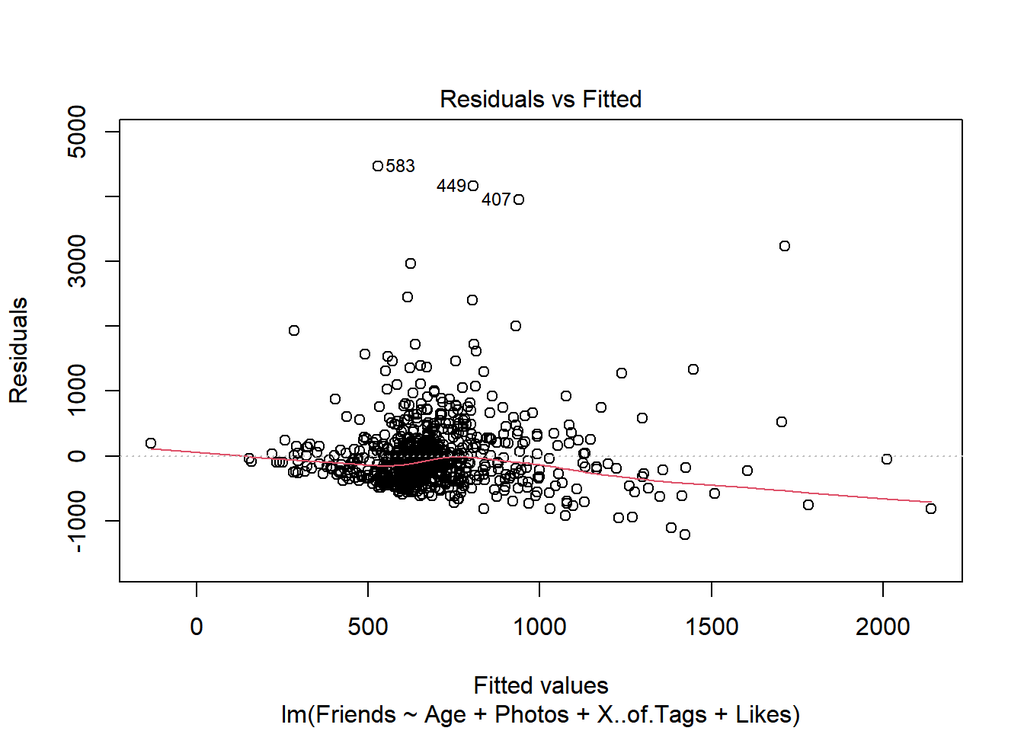

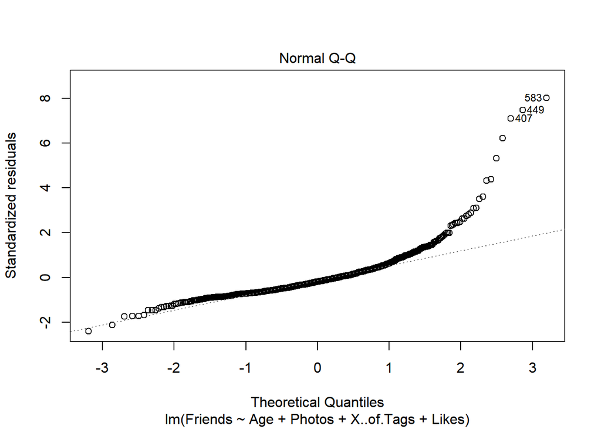

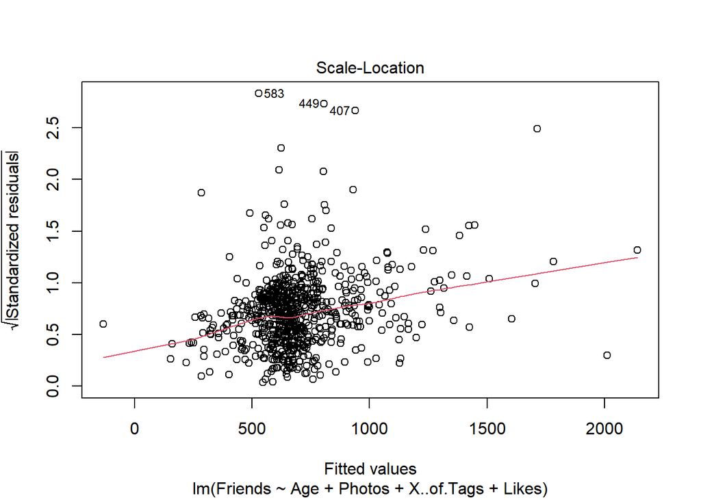

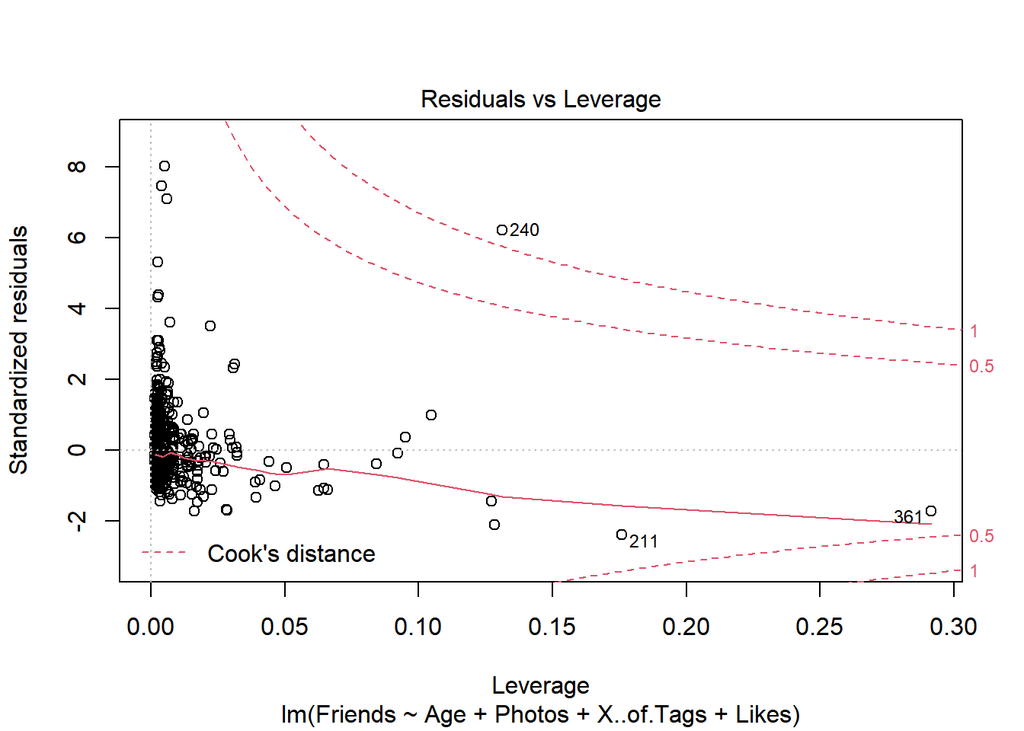

```r
plot(model3)
```

#Let’s check the number if friends at 14th row.

```r
fbfriend[14, 1:17]
```

```
##    Age Photos X..of.Tags Albums Gender Emp Profile Cover Orientation
## 14  24    402        504     13      1   1       1     0           1
##    Relationship Posts Replies Children Likes Edu Events Friends
## 14            1   421     321        0   113   0      5     519
```

```r
predict(model3,list(Age=24,X..of.Tags=504, Likes=113, Photos=402))
```

```
##        1
## 670.7685
```

```r
model4<-lm(log(Friends) ~ Age + Photos + X..of.Tags + Likes)
summary(model4)
```

```
##
## Call:
## lm(formula = log(Friends) ~ Age + Photos + X..of.Tags + Likes)
##
## Residuals:
##     Min      1Q  Median      3Q     Max
## -4.8516 -0.4393  0.0859  0.4950  2.6902
##
## Coefficients:
##               Estimate Std. Error t value Pr(>|t|)
## (Intercept)  6.757e+00  1.182e-01  57.167  < 2e-16 ***
## Age         -3.095e-02  4.367e-03  -7.087 3.31e-12 ***
## Photos       1.122e-04  2.788e-05   4.025 6.32e-05 ***
## X..of.Tags   1.692e-04  4.894e-05   3.458 0.000577 ***
## Likes        4.056e-04  1.163e-04   3.487 0.000518 ***
## ---
## Signif. codes:  0 '***' 0.001 '**' 0.01 '*' 0.05 '.' 0.1 ' ' 1
##
## Residual standard error: 0.796 on 710 degrees of freedom
## Multiple R-squared:  0.178,  Adjusted R-squared:  0.1733
## F-statistic: 38.43 on 4 and 710 DF,  p-value: < 2.2e-16
```